# cw8

Patrycja Sarga

2023-05-12

## Zadanie1: Dlaczego w modelu $y=ax+b + \epsilon$ możemy założyć, że $\epsilon$ ma wartość oczekiwaną 0?

Jeżeli model jest dobrze dopasowany do danych, to będzie mieć on wartość oczekiwaną 0. Model liniowy z założenia jest budowany w taki sposób, aby suma kwadratów reszt (SSR) była możliwie najmniejsza, bo to właśnie oznacza dobrze dopasowany model. Zatem, jeżeli dążymy do uzyskania małych wartośći SSR, to również małe muszą być same reszty - zwykle są bliskie 0.

## Zadanie2: Zbuduj model regresji liniowej. Poszukujemy zależności wartości odżywczych płatków (rating) od zawartości cukrów (sugars). Dodatkowo:

- oblicz i zinterpretuj współczynnik korelacji,
- zbuduj model liniowy, skomentuj otrzymane parametry oraz dokonaj wstępęj diagnostyki modelu,
- jaka będzie przewidywana wartość płatków z zerową wartością odżywczą?
- o ile wzrośnie lub zmaleje wartość odżywcza płatków jeżeli zawartość cukrów wzrośnie o 1 gram?
- wyznacz obserwacje nietypowe

```r
#install.packages("liver")
library(liver)
data(cereal)
head(cereal)
```

```
##                        name manuf type calories protein fat sodium fiber carbo
## 1                 100% Bran     N cold       70       4   1    130  10.0   5.0
## 2         100% Natural Bran     Q cold      120       3   5     15   2.0   8.0
## 3                  All-Bran     K cold       70       4   1    260   9.0   7.0
## 4 All-Bran with Extra Fiber     K cold       50       4   0    140  14.0   8.0
## 5            Almond Delight     R cold      110       2   2    200   1.0  14.0
## 6   Apple Cinnamon Cheerios     G cold      110       2   2    180   1.5  10.5
##   sugars potass vitamins shelf weight cups   rating
## 1      6    280       25     3      1 0.33 68.40297
## 2      8    135        0     3      1 1.00 33.98368
## 3      5    320       25     3      1 0.33 59.42551
## 4      0    330       25     3      1 0.50 93.70491
## 5      8     -1       25     3      1 0.75 34.38484
## 6     10     70       25     1      1 0.75 29.50954
```

```r
#oblicz i zinterpretuj współczynnik korelacji

x = cereal$sugars
y = cereal$rating

cor(x,y)
```

```
## [1] -0.7596747
```

Obserwowany współczynnik korelacji jest wystarczająco wysoki, aby stwierdzić zależność między dwoma czynnikami.

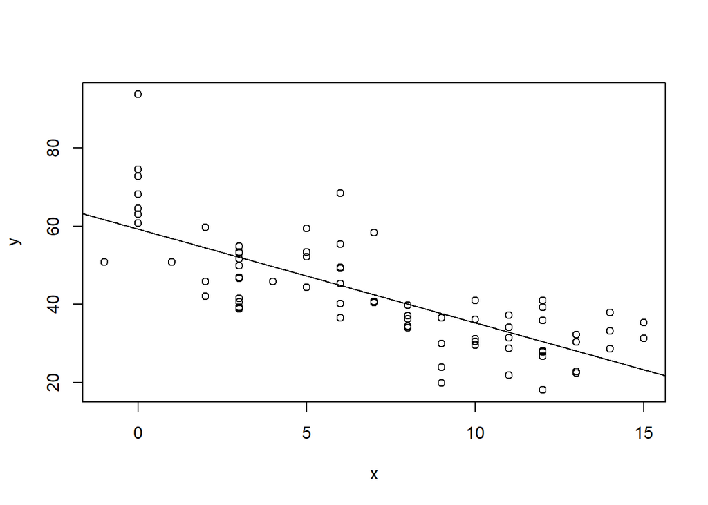

```r
# zbuduj model liniowy, skomentuj otrzymane parametry oraz dokonaj wstępnej diagnostyki modelu


model = lm(y~x)
plot(x,y)
abline(model)
```

```r
summary(model)
```

```
##
## Call:
## lm(formula = y ~ x)
##
## Residuals:
##     Min      1Q  Median      3Q     Max
## -17.853  -5.677  -1.439   5.160  34.421
##
## Coefficients:
##             Estimate Std. Error t value Pr(>|t|)
## (Intercept)  59.2844     1.9485   30.43  < 2e-16 ***
## x            -2.4008     0.2373  -10.12 1.15e-15 ***
## ---
## Signif. codes:  0 '***' 0.001 '**' 0.01 '*' 0.05 '.' 0.1 ' ' 1
##
## Residual standard error: 9.196 on 75 degrees of freedom
## Multiple R-squared:  0.5771, Adjusted R-squared:  0.5715
## F-statistic: 102.3 on 1 and 75 DF,  p-value: 1.153e-15
```

Z powyższego podsymowania wyciągamy m. in. następujące informacje dotyczace reszt:  
* minimalna wartość: -17.853  
* maksymalna: 34.421  
* mediana: -1. 439

Otrzymujemy również informacje na temat samego modelu:  
* model jest opisany równaniem y = -2.4008x + 59.2844  
Oszacowane wartości parametrów a i b (y=ax+b) są istotne statystycznie (p<0.05)  
* błąd standardowy wynosi 9.196 - dość duży rozrzut danych * R-squared = 0.5771, co wskazuje na nienajlepsze dopasowanie danych do modelu

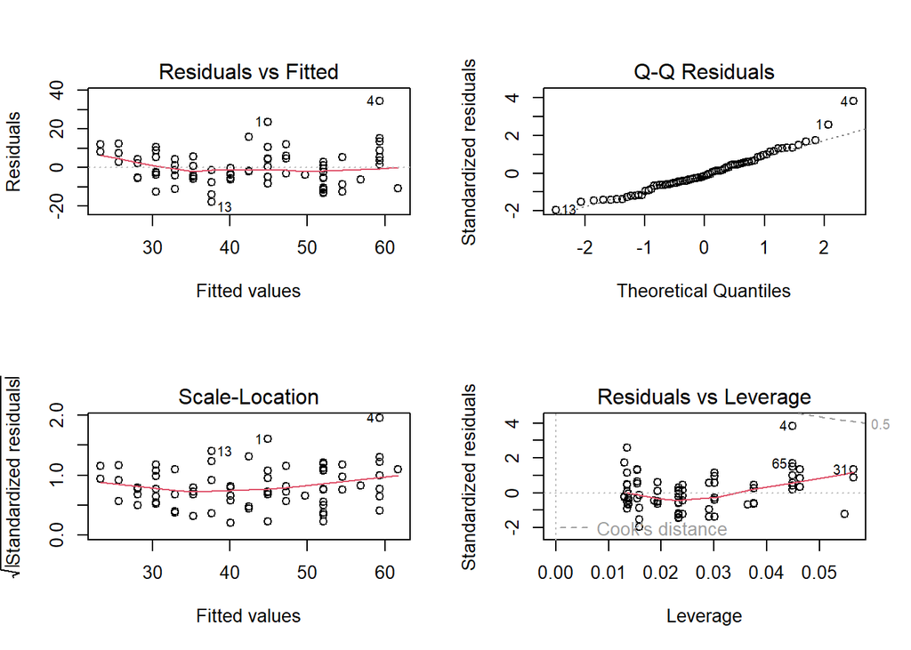

```r
options(repr.plot.width=10, repr.plot.height=5)

par(mfrow = c(2, 2));
plot(model)
```

Wykres Residuals vs Fitted wskazuje na dość symetryczny rozrzut reszt względem 0 - nieznacznie odbiega początkowy i końcowy fragment wykresu.

Q-Q Residuals prezentuje punkty pokrywającie się z przerywaną linią (odstające dwa punkty na końcu wykresu) - co świadczy o normalności rokzładu

Istotną informację niesie jeszcze ostatni wykres Residuals vs Leverage, który wskazuje na wystepowanie wartośći odstających

```r
n = length(x)
y_pred = -2.4008*x+59.2844
ei = y - y_pred
Su = sqrt(sum(ei^2)/(n-2))
dzwignia = 1/n + (x-mean(x))^2/sum((x-mean(x))^2)
Sei = Su*sqrt(1 - (dzwignia))
ri = ei/Sei
```

Jaka będzie przewidywana wartość płatków z zerową wartością odżywczą? * x=0, zatem y = 59.2844

O ile wzrośnie lub zmaleje wartość odżywcza płatków jeżeli zawartość cukrów wzrośnie o 1 gram?  
* y = -2.4008(x + 1) + 59.2844

Wyznacz obserwacje nietypowe

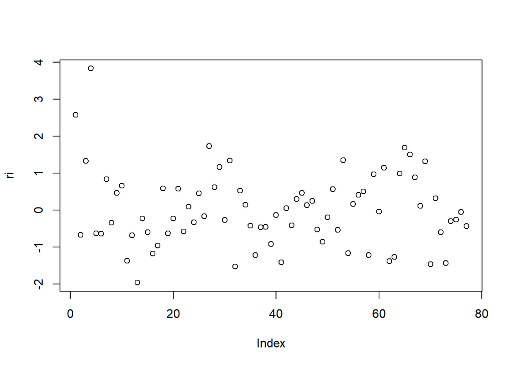

```r
plot(ri) #wykres standaryzowanych reszt
```

```r
#zaimplementowana w R
jack = rstudent(model) #pozwala znajdywac obserwacje odstajace
jack
```

```
##           1           2           3           4           5           6
##  2.67963749 -0.66483564  1.33806879  4.24185388 -0.62083484 -0.63069251
##           7           8           9          10          11          12
##  0.83361783 -0.33082343  0.46188855  0.65875417 -1.38103926 -0.67533952
##          13          14          15          16          17          18
## -1.99561459 -0.22605977 -0.58905353 -1.17333536 -0.95067357  0.58357934
##          19          20          21          22          23          24
## -0.62676382 -0.22077417  0.58153986 -0.56807319  0.09817836 -0.32130633
##          25          26          27          28          29          30
##  0.45581261 -0.15741144  1.76090138  0.61686792  1.16678092 -0.26872565
##          31          32          33          34          35          36
##  1.34852518 -1.53441429  0.52314113  0.14091247 -0.42243248 -1.21515759
##          37          38          39          40          41          42
## -0.45920569 -0.45253074 -0.91387540 -0.13127498 -1.42250834  0.04879274
##          43          44          45          46          47          48
## -0.41069369  0.30282948  0.46665025  0.13827246  0.24670476 -0.52010554
##          49          50          51          52          53          54
## -0.84825632 -0.19427062  0.56691529 -0.52731814  1.36268886 -1.16676092
##          55          56          57          58          59          60
##  0.16269934  0.41177952  0.50468265 -1.21828496  0.96965555 -0.04072487
##          61          62          63          64          65          66
##  1.14699129 -1.38621831 -1.27299637  0.99601082  1.71168775  1.51712233
##          67          68          69          70          71          72
##  0.88967274  0.11470734  1.33112918 -1.46824717  0.32320644 -0.59413190
##          73          74          75          76          77
## -1.43787246 -0.29865990 -0.25088253 -0.05352496 -0.42365557
```

```r
jack[which.max(abs(jack))] #gdzie najwieksza wartosc?
```

```
##        4
## 4.241854
```

```r
library(car)
outlierTest(model)
```

```
##   rstudent unadjusted p-value Bonferroni p
## 4 4.241854         6.3353e-05    0.0048782
```

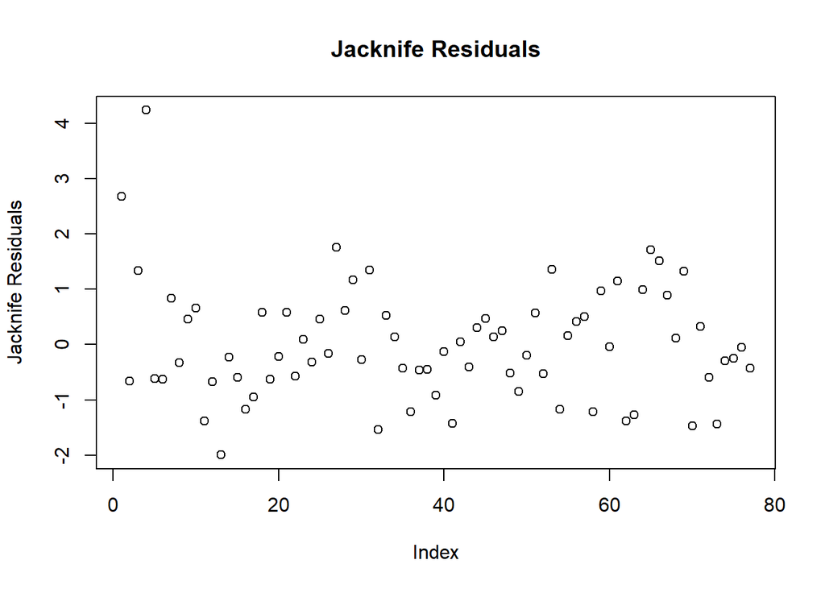

```r
plot(jack, ylab="Jacknife Residuals", main="Jacknife Residuals")
```

Na powyższym wykresie obserwujemy jedną wartość znacząco odstającą - na pozycji 4

```r
cutoff = 4/(n-length(model$coefficients)-2) #graniczny poziom  4/(n-k-2)

print(cutoff)
```

```
## [1] 0.05479452
```

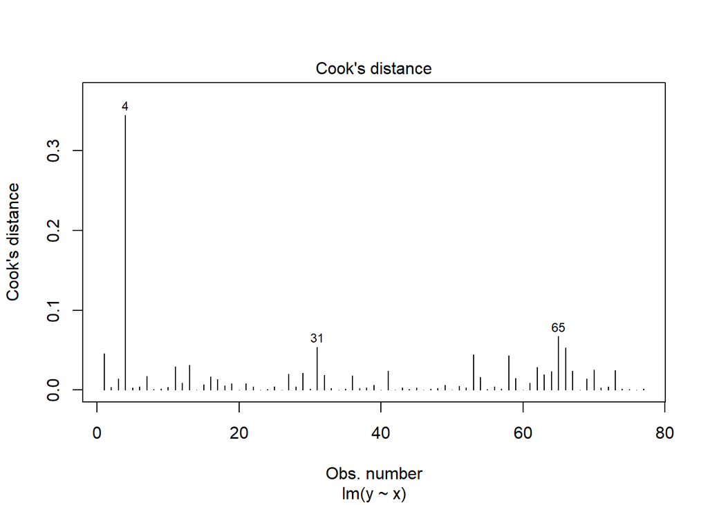

```r
plot(model, which=4, cook.levels=cutoff) #odleglosc cooka, mierzy jak usunięcie danej obserwacji wplywa na wspolczynniki modelu (dokladniej na y_pred), jest proporcjonalna do (y_predALL - y_pred)^2, jak wysoka to obserwacja jest wplywowa
```

Wykres Cook’s Distance wskazuje na wartości wpływowe - wspomniana wcześniej wartość odstająca na pozycji 4 ma duży wpływ na model. Wykres wskazuje również nieznacznie wyższy od pozostałych wpływ obserwacji 31 i 65 - jest on jednak znacznie mniejszy niż w przypadku obserwacji 4.

## Zadanie3: Na poprzednich zajęciach rozmawialiśmy o transformacjach danych (m.in. logarytm czy pierwiastek). Zapoznaj się z szerszą klasą takich przekształceń (https://core.ac.uk/download/pdf/239584602.pdf); w szczególności strony 1-4. Jakie cechy mają te transformacje? Sporządź zwięzłą notatkę na ten temat.

Użycie testów statystycznych wymaga, aby analizowane dane spełniały pewne założenia. Najpopularniejsze z nich to normalność rozkładu danych oraz równość wariancji. Aby sprawdzić czy założenia te zachodzą, często praktykuje się obserwacje danych poprzez przegląd wartości jakie zawierają czy też ich wizualizację. Warto jednak wykorzystać bardziej wyrafinowane narzędzia przeznaczone do tego celu, np.:
* Zbadanie skośności – powinna mieścić się w zakresie [-0.8, 0.8]
* Zbadanie kurtozy – w większości programów powinna być zbliżona do wartości 3.0
* Test Kołmorogowa-Smirnowa
* Test Shapiro-Wilka (p-value powinno być większe od 0.5)
Jeżeli dla analizowanych danych wymienione założenia nie są spełnione wymagane jest wykonanie transformacji. W teorii dostępnych jest tyle transformacji danych, ile istnieje operacji matematycznych, w praktyce natomiast najczęściej wykorzystuje się:
* Pierwiastkowanie danych, przy obecności ujemnych wartości w danych wzbogacone o dodawanie stałej, by przesunąć wartość minimalną powyżej 0.0 lub nawet 1.0 (należy pamiętać, że pierwiastkowanie liczb w zakresie [0.0,1.0] wygląda inaczej niż dla wartości większych od 1.0). Ta operacja najlepiej się sprawdza do transformacji danych o rozkładzie Poissona
* Transformacja logarytmiczna – najczęściej logarytm dziesiętny lub naturalny. Podobnie jak przy pierwiastkowaniu występuje różnica w efekcie przekształcania liczb z zakresu [0.0,1.0] a większych
* Odwracanie danych – przekształca małe liczby w duże, a duże – w małe
* Transformacja arcsin, a więc przekształcanie danych do zakresu [-1.0,1.0]
Większość współcześnie stosowanych transformacji można zawęzić do operacji potęgowania. Jest ona w artykule określona mianem transformacji Box-Coxa i opiera się na równaniu
$$y^{lambda} = (y^{lambda} - 1) / lambda$$
gdzie y to wartość zmiennej numerycznej, a lambda to parametr transformacji, który może przyjmować różne wartości. Przy pomocy niektórych pakietów statystycznych można oszacować parametr lambda tak, aby uzyskać możliwie najlepsza transformacje dla swojego zestawu danych.